# Analysis of Daily Activity Patterns: Comparing Weekday and Weekend Step Counts

### 2. What is the average daily activity pattern?

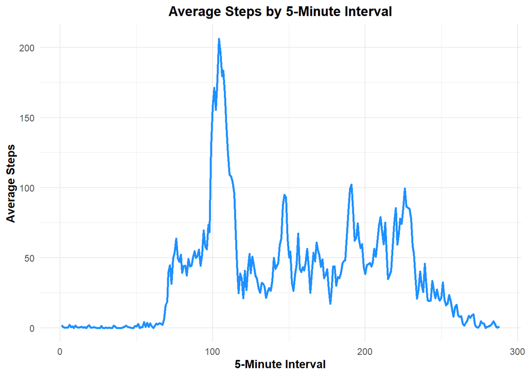

```r
activity$interval <- as.numeric(activity$interval)

average_step <- activity %>% group_by(interval) %>% summarize(avg_step = mean(steps, na.rm = TRUE))


ggplot(average_step, aes(x = interval, y = avg_step)) +
  geom_line(color = "dodgerblue", size = 1) +
  labs(
    title = "Average Steps by 5-Minute Interval",
    x = "5-Minute Interval",
    y = "Average Steps"
  ) +
  theme_minimal() +
  theme(
    plot.title = element_text(hjust = 0.5, face = "bold"),
    axis.title = element_text(face = "bold")
  )
```

```r
### which 5 minute interval has the most steps walked
z <- average_step %>%  filter(avg_step == max(avg_step))
```

The summary statisics and the time-series plot reveal that the 5-minute interval with the maximum number of steps is 104, 206.1698113

### 3. Imputing Missing Values

#### 3.1 Total number of missing values in the dataset

```r
### Dealing with missing values
z <- sum(is.na(activity)) ### Total number of NAs in the dataset
```

The total number of missing values in the dataset is 2304

#### 3.2 Filling NAs with the overall average of steps taken per day

```r
### average step per day
day_step_average <- activity %>% group_by(date) %>% summarize(avg_step = mean(steps, na.rm = TRUE))

sum(is.na(day_step_average))
```

```
## [1] 8
```

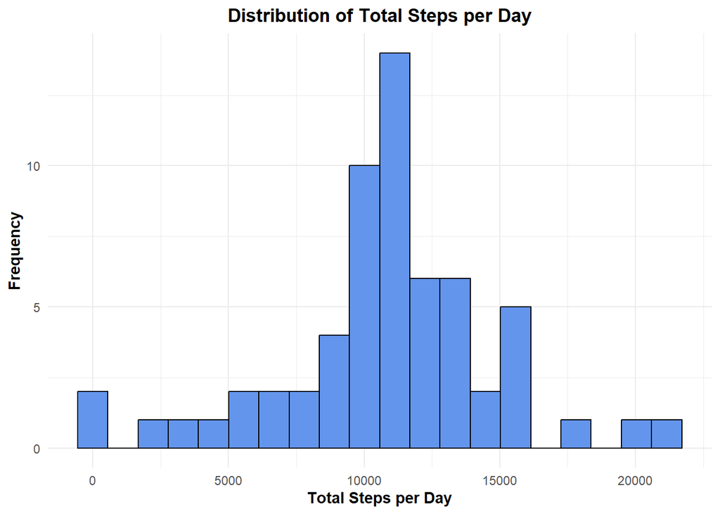

```r
### Replacing the NAs with the average of total steps in the dataset

revised_data <- activity %>% mutate (new_steps = if_else(is.na(steps), 37.3826, steps)) %>% select(- steps)

step_per_day <- revised_data %>% group_by(date) %>% summarize(total_steps_day = sum(new_steps))

ggplot(step_per_day, aes(x = total_steps_day)) +
  geom_histogram(fill = "cornflowerblue", color = "black", bins = 20) +
  labs(
    title = "Distribution of Total Steps per Day",
    x = "Total Steps per Day",
    y = "Frequency"
  ) +
  theme_minimal() +
  theme(
    plot.title = element_text(hjust = 0.5, face = "bold"),
    axis.title = element_text(face = "bold")
  )
```

```r
x <- mean(revised_data$new_steps)
y <- median(revised_data$new_steps)
```

The missing values in the dataset was filled with the overall average of the number of steps taken. The histogram plot reveales the differences between the distribution of steps without missing values. The revised mean after filling the missiong values is 37.3826 and the median of the number steps taken after filling the missing values is 0.